# Analysis for John

Joseph Bulbulia

09/11/2020

```r
# get data frame in read for analysis
js<-js1%>%
  dplyr::mutate(male =factor(ifelse(sex==1,"male","not_male"))) %>% # fix bad coding
  dplyr::mutate(id = factor(id) )%>%
  dplyr::select(-church_at_risk) %>%  # we don't want this in our models -- if you can't attend it doesnt' count
  dplyr::mutate(church_attendF = factor(church_attend))%>%
  dplyr::mutate(timeF = factor(time)) %>%
  dplyr::mutate(church_event_noF = factor(church_event_no))%>%
  dplyr::mutate(church_dateF = factor(church_dateR),
                kava_dateF = factor(kava_date),
                reported_attendanceF = factor(reported_attendance),
                church_donationF = factor(church_donation),
                church_donationN = as.numeric(church_donationF),
                church_donationC = scale(church_donationN,center=T,scale=F),
                village_donationF = factor(village_donation),
                village_donationN = as.numeric(village_donationF),
                village_rankN = as.numeric(village_rank),
                village_rankS = scale(village_rankN))%>%
  arrange(id)
```

The purpose of our study is to investigate how religious attendance affects cooperation via religious reptuational pathways.

But before we get to that, we explore the data

```r
# So, some basic correlations to investigate relationships.
library(correlation)
library(see) # for plotting
library(ggraph) # needs to be loaded
js %>%
  dplyr::select(cooperative_reputation,religious_reputation)%>%
  correlation(partial = TRUE) %>%
  summary()
```

```
#> Parameter              | religious_reputation
#> ---------------------------------------------
#> cooperative_reputation |              0.68***
```

```r
js %>%
  dplyr::select(cooperative_reputation,church_donationN)%>%
  correlation(partial = TRUE) %>%
  summary()
```

```
#> Parameter              | church_donationN
#> -----------------------------------------
#> cooperative_reputation |          0.34***
```

```r
js %>%
  dplyr::select(religious_reputation,church_donationN)%>%
  correlation(partial = TRUE) %>%
  summary()
```

```
#> Parameter            | church_donationN
#> ---------------------------------------
#> religious_reputation |          0.41***
```

```r
js %>%
  dplyr::select(cooperative_reputation,village_donationN)%>%
  correlation(partial = TRUE) %>%
  summary()
```

```
#> Parameter              | village_donationN
#> ------------------------------------------
#> cooperative_reputation |           0.06***
```

```r
js %>%
  dplyr::select(religious_reputation,village_donationN)%>%
  correlation(partial = TRUE) %>%
  summary()
```

```
#> Parameter            | village_donationN
#> ----------------------------------------
#> religious_reputation |           0.23***
```

```r
js %>%
  dplyr::select(church_attend,church_donationN)%>%
  correlation(partial = TRUE) %>%
  summary()
```

```
#> Parameter     | church_donationN
#> --------------------------------
#> church_attend |          0.09***
```

```r
js %>%
  dplyr::select(religious_reputation,church_donationN)%>%
  correlation(partial = TRUE) %>%
  summary()
```

```
#> Parameter            | church_donationN
#> ---------------------------------------
#> religious_reputation |          0.41***
```

```r
js %>%
  dplyr::select(church_attend,church_donationN)%>%
  correlation(partial = TRUE) %>%
  summary()
```

```
#> Parameter     | church_donationN
#> --------------------------------
#> church_attend |          0.09***
```

```r
js %>%
  dplyr::select(religious_reputation,village_donationN)%>%
  correlation(partial = TRUE) %>%
  summary()
```

```
#> Parameter            | village_donationN
#> ----------------------------------------
#> religious_reputation |           0.23***
```

```r
js %>%
  dplyr::select(religious_reputation,reported_attendance)%>%
  correlation(partial = TRUE) %>%
  summary()
```

```
#> Parameter            | reported_attendance
#> ------------------------------------------
#> religious_reputation |             0.25***
```

```r
# we could carry on with more correlations, but lets hold off on that
```

No, to replicate the study John and Martin’s study. Not that we really need to assess the ordering of the event within in date (whether first, second or third.) I (JB) need to understand John’s coding better before we can do that.

```r
# Let's get on to some modelling. This is the model that John and Martin are running (I think)
library(brms)
# because I can't get the dates right, I'll assume need the date factor.
# does reported attendance predict attendance bu wed
# only the church data

m1 <-
  brm(data = js, family = bernoulli,
      church_attend  ~ male + reported_attendanceF  + (1|church_dateF/id),
      prior(normal(0, 10), class = Intercept),
      seed = 10,
      file = here("m1"))
#summary(m1) # ugly
```

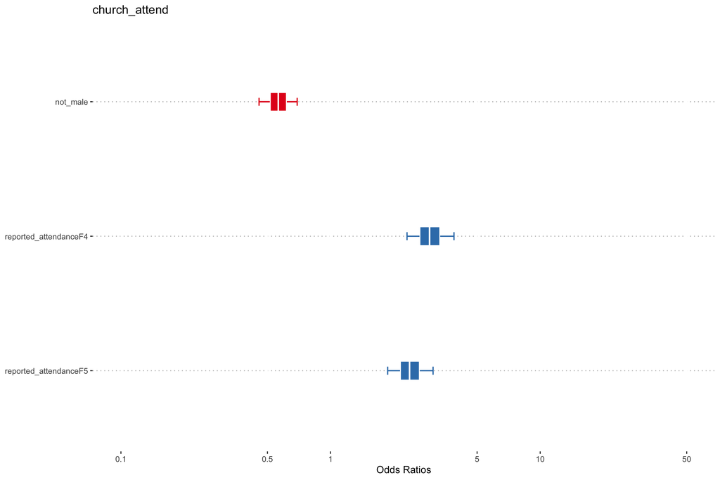

|  | church_attend |  |
| --- | --- | --- |
| Predictors | Odds Ratios | CI (95%) |
| Intercept | 0.76 | 0.56 – 1.00 |
| male: not_male | 0.56 | 0.43 – 0.73 |
| reported_attendanceF: reported_attendanceF4 | 2.97 | 2.19 – 4.08 |
| reported_attendanceF: reported_attendanceF5 | 2.38 | 1.79 – 3.26 |
| N <sub>id</sub> | 45 |  |
| N <sub>church_dateF</sub> | 24 |  |
| Observations | 1877 |  |
| Marginal R<sup>2</sup> / Conditional R<sup>2</sup> | 0.048 / 0.175 |  |

Here is a figure showing the predicted probabilities for male/not males. I don’t know the coding but I could guess.

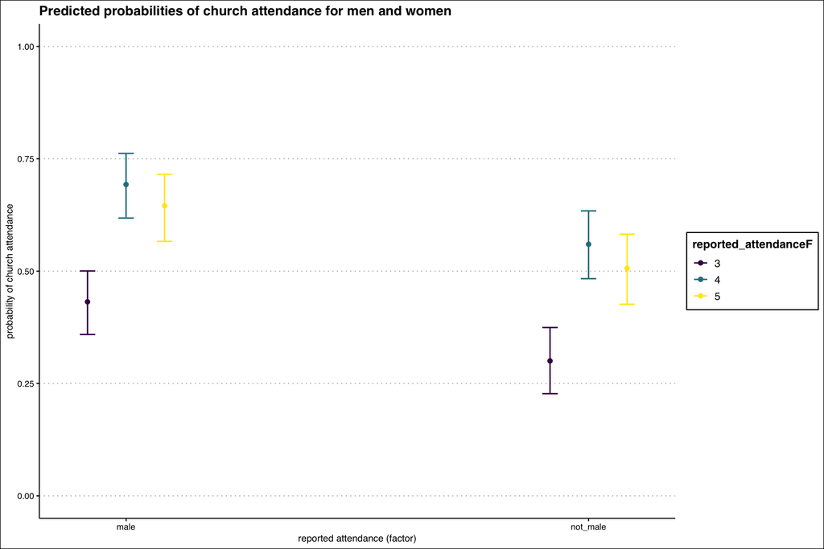

```r
gp<-ggpredict(m1, terms =c("male","reported_attendanceF"))
p1<-plot(gp, facets = F, color="viridis") + scale_y_continuous(limits=c(0,1)) + theme_clean()
p1 + xlab("reported attendance (factor)") + ylab("probability of church attendance") + ggtitle("Predicted probabilities of church attendance for men and women")
```

```r
#now the main show, the mediation model, get data into shape

df1<-js%>%
 # dplyr::filter(church_at_riskF ==1)%>% # needs to be able to be at church
  dplyr::filter(!is.na(church_attend),!is.na(cooperative_reputation),!is.na(church_donationN))%>%
  dplyr::group_by(id, church_attend) %>%
  summarise(n = n()) %>%
  mutate(churchfreq = n / sum(n))%>%
  filter(church_attend !=0)%>%
  ungroup()%>%
  dplyr::select(id,churchfreq)
nrow(df1) ##44
```

```
#> [1] 44
```

Ok, we merge this now.

```r
df2 <- js %>%
   dplyr::select(id, cooperative_reputation,church_donationN)%>%
  distinct(id,.keep_all = TRUE)

jj1 <-merge (df1, df2, by.y = 'id')
nrow(jj1)
```

```
#> [1] 44
```

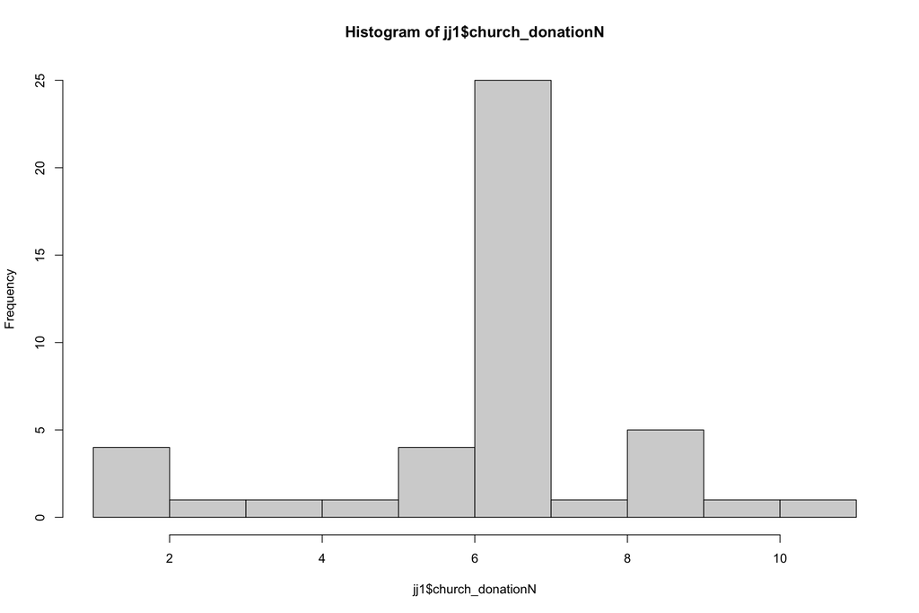

```r
# inspect histograms
hist(jj1$church_donationN, breaks=10) # zeven is modal
```

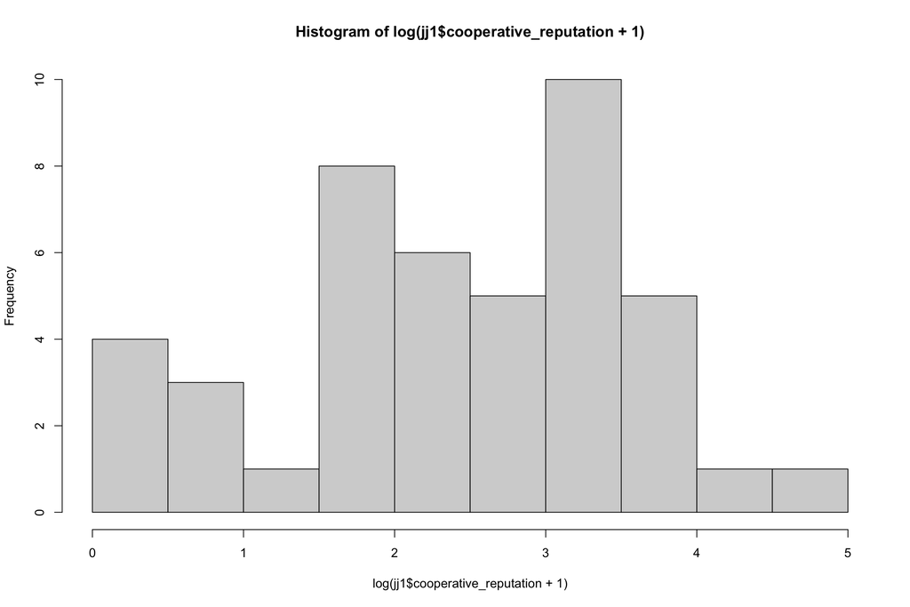

```r
hist(log(jj1$cooperative_reputation+1)) # better
```

Put reputation on the log scale.

BRMS MODEL

```
#>  Family: MV(gaussian, gaussian)
#>   Links: mu = identity; sigma = identity
#>          mu = identity; sigma = identity
#> Formula: cooperativereputationLOG ~ churchfreq
#>          churchdonationN ~ churchfreq + cooperativereputationLOG
#>    Data: jj2 (Number of observations: 44)
#> Samples: 4 chains, each with iter = 10000; warmup = 5000; thin = 1;
#>          total post-warmup samples = 20000
#>
#> Population-Level Effects:
#>                                          Estimate Est.Error l-95% CI u-95% CI
#> cooperativereputationLOG_Intercept           1.01      0.46     0.08     1.90
#> churchdonationN_Intercept                    5.21      0.90     3.43     6.97
#> cooperativereputationLOG_churchfreq          2.55      0.80     1.01     4.13
#> churchdonationN_churchfreq                   1.14      1.62    -2.04     4.31
#> churchdonationN_cooperativereputationLOG     0.34      0.29    -0.23     0.93
#>                                          Rhat Bulk_ESS Tail_ESS
#> cooperativereputationLOG_Intercept       1.00    30841    14932
#> churchdonationN_Intercept                1.00    27582    16182
#> cooperativereputationLOG_churchfreq      1.00    30623    14335
#> churchdonationN_churchfreq               1.00    23952    15745
#> churchdonationN_cooperativereputationLOG 1.00    23039    14982
#>
#> Family Specific Parameters:
#>                                Estimate Est.Error l-95% CI u-95% CI Rhat
#> sigma_cooperativereputationLOG     1.12      0.13     0.91     1.40 1.00
#> sigma_churchdonationN              2.08      0.23     1.68     2.60 1.00
#>                                Bulk_ESS Tail_ESS
#> sigma_cooperativereputationLOG    27117    13572
#> sigma_churchdonationN             27128    13868
#>
#> Samples were drawn using sampling(NUTS). For each parameter, Bulk_ESS
#> and Tail_ESS are effective sample size measures, and Rhat is the potential
#> scale reduction factor on split chains (at convergence, Rhat = 1).
```

Table for results

```r
#summary
tab_model(m2)
```

|  | churchdonationN |  | cooperativereputationLOG |  |
| --- | --- | --- | --- | --- |
| Predictors | Estimates | CI (95%) | Estimates | CI (95%) |
| Intercept | 5.21 | 3.43 – 6.97 | 1.01 | 0.08 – 1.90 |
| churchfreq | 1.16 | -2.04 – 4.31 | 2.54 | 1.01 – 4.13 |
| cooperativereputationLOG | 0.34 | -0.23 – 0.93 |  |  |
| Observations | 44 |  |  |  |

Code for a figure

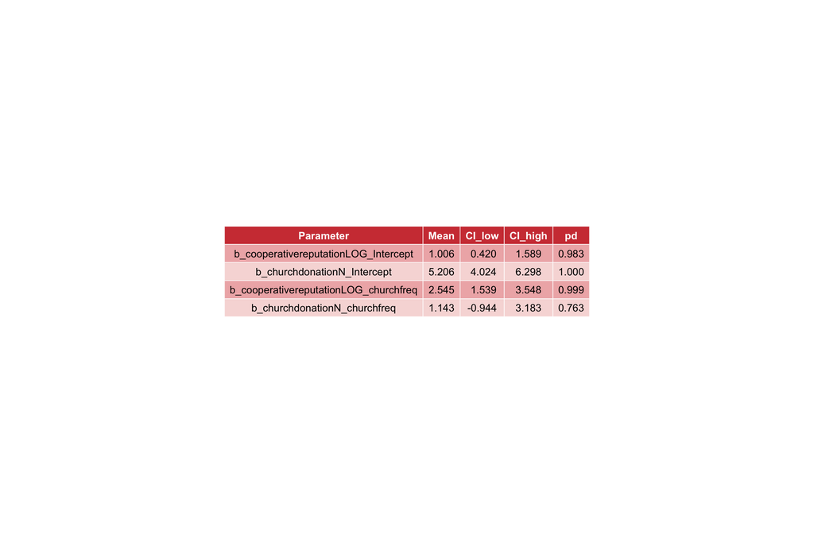

```r
library(bayestestR)
bbt1<-bayestestR::mediation(m2,centrality = "mean")
library(ggpubr)
pt1<-bayestestR::describe_posterior(as.data.frame(m2),centrality = "mean", test="p_direction",ci=.8)%>%
  tibble::as_tibble(include.rownames = FALSE)%>%
  dplyr::slice(n=1:4)%>%
  dplyr::select(-CI)%>%
  mutate_if(is.numeric, ~round(., 3))%>%
  ggpubr::ggtexttable(rows = NULL,
                      theme = ttheme("mRed"))
pt1
```

```r
pm1<-as.data.frame(bbt1)%>%
  dplyr::select(-proportion_mediated)%>%
  bayesplot::mcmc_intervals()%>%
  ggpar(main = "cooperative_reputationLOG")
dm1<-as.data.frame(bbt1)%>%
  dplyr::select(-proportion_mediated)%>%
  bayestestR::estimate_density()%>%
  plot(labels = FALSE)%>%
  ggpar(main = "")
r1<-brms::conditional_effects(m2, "churchfreq", resp ="cooperativereputationLOG")
r7<-brms::conditional_effects(m2, "churchfreq", resp ="churchdonationN", categorical =F)
r8<-brms::conditional_effects(m2, "cooperativereputationLOG", resp ="churchdonationN", categorical =F)
```

Plot 1

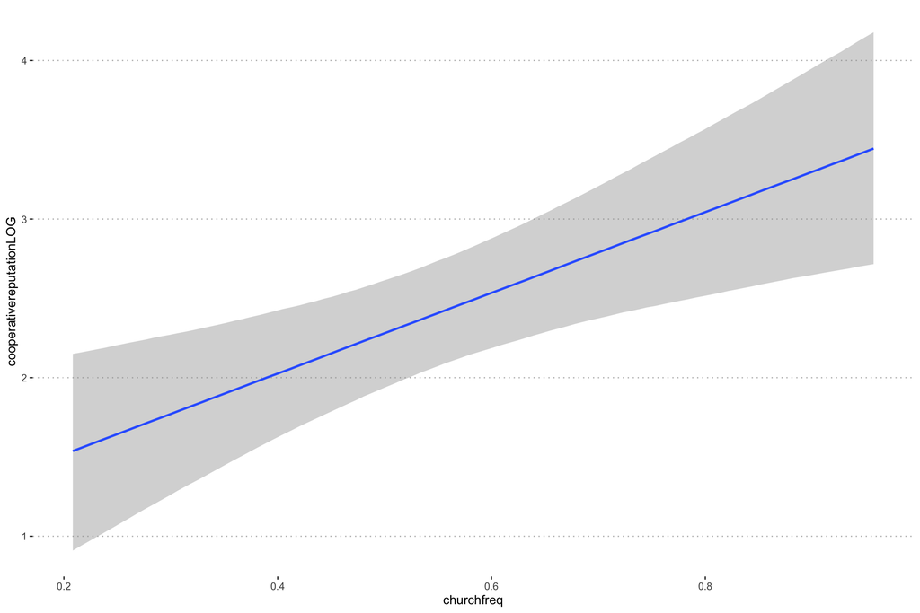

```r
r1
```

Plot 2

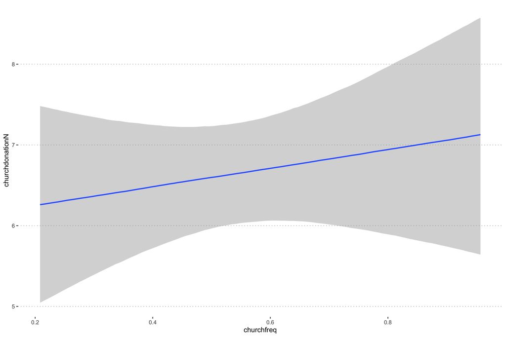

```r
r7
```

Plot 3

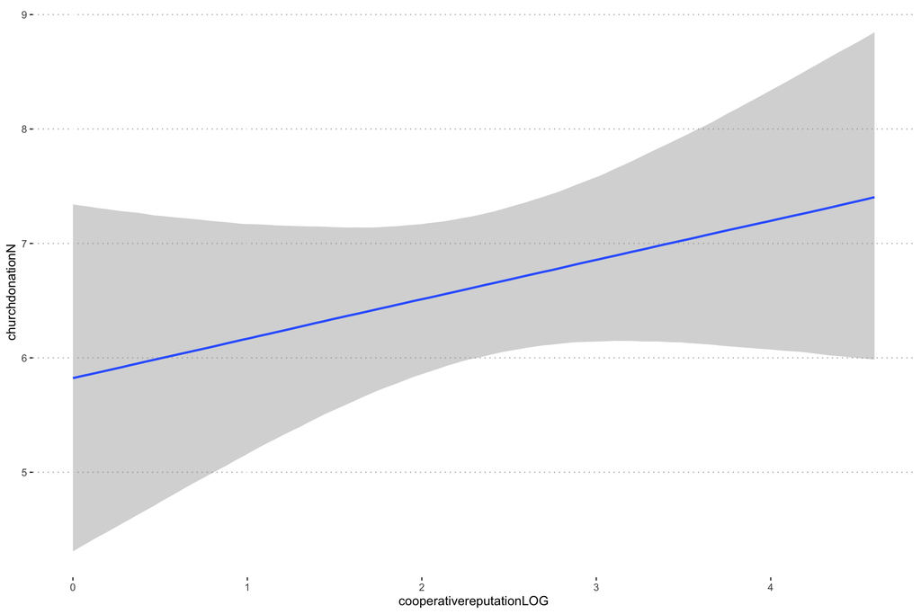

[figure not shown]

```r
r8
```

Needs stronger priors here (44 cases only). Looks like there is something here. more to be done